# 第6回 区分を当て、見逃しを数える

ロジスティック回帰・混同行列・適合率と再現率・ROC

# 導入

## ずっと、数を当ててきた

- 利用台数、1泊の料金、住宅価格
- 回帰の道具は、ひととおりそろった

## 今日は、区分を当てる

- 当てる相手は、「心臓病あり／なし」の二択
- あなたは、健診センターの医師

## 2つの間違いは、重さが違う

- 病気の人を「健康」と帰すのが、見逃し。治療の機会を失う
- 健康な人を「病気」と言うのが、誤検出。再検査で済む

## 今日の問い

心臓病の疑いがある人を見つけ出し、何人を見逃すかを数で言えるか？

## 今日のコードの書き方

- 配列どうしを比べて、True/Falseの並びを作る
- `.sum()`でTrueの数、`.mean()`でTrueの割合
- 判定と答えの組み合わせの人数を、自分で数える

## この問いに、どう近づくか

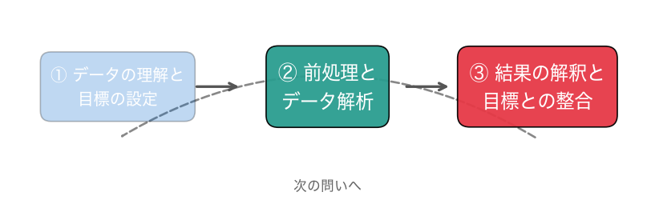

②の解析と、③の解釈が中心です。

# 0. 設定

## やってみよう：0節

- 第6回のノートを開き、ドライブにコピーする
- 0節の設定のセルを実行し、「セットアップ完了」を確かめる

動画の人は、ここで一時停止。

# 1. どんな人たちのデータか

## まず、どんな人たちかを見る

- 見つけ出す前に、心臓病あり・なしの人たちを比べる

## お手本：2つのグループを比べる

```python
# データはこのリポジトリから読み込む
DATA_DIR = ('https://raw.githubusercontent.com/k0heiun0/'
            'applied_exercise_preview/main/shared/data')
df = pd.read_csv(f'{DATA_DIR}/heart.csv')
print((df['target'] == 1).sum(), '人が心臓病あり /', len(df), '人')
cols = ['age', 'thalach', 'oldpeak']
print(df.groupby('target')[cols].mean().round(1))
```

- 役割：心臓病あり・なしの人数と、主な検査値の平均を比べる

## おさらい：def

```python
def 名前(引数):
    return 戻り値
```

- `def`の後ろが名前と引数（入力）、`return`の後ろが戻り値（出力）（第3回）
- 第3回の`prep`（補う値と物差しを訓練で決めて整える）を、今日も使う
- 今日は、使う列の並びも引数`cols`で渡す

## 変えてみる：prepで整える

```python
feat = [c for c in df.columns if c != 'target']      # 13本の検査値
tr, te = train_test_split(df, test_size=0.2, random_state=42,
                          stratify=df['target'])
y_tr, y_te = tr['target'].values, te['target'].values

def prep(base, df_in, cols):  # 物差しは base で決める（第3回）
    med = base[cols].median()
    Xb = base[cols].fillna(med).values
    X = df_in[cols].fillna(med).values
    return (X - Xb.mean(axis=0)) / Xb.std(axis=0)

Z_tr, Z_te = prep(tr, tr, feat), prep(tr, te, feat)
print(len(y_tr), len(y_te))
```

## stratifyで、割合をそろえる

```python
tr, te = train_test_split(df, test_size=0.2, random_state=42,
                          stratify=df['target'])
```

- 訓練とテストで、心臓病ありの割合がそろうように分ける
- 訓練242人、テスト61人

## やってみよう：1節

- 1節のお手本と「変えてみる」のセルを実行する
- 心臓病の人と、そうでない人で、何が違うか？

動画の人は、ここで一時停止。

## 答え合わせ：ほぼ半々

```
139 人が心臓病あり / 303 人
```

- 303人のうち、心臓病ありが139人

## 答え合わせ：平均の違い

```
         age  thalach  oldpeak
target
0       52.6    158.4      0.6
1       56.6    139.3      1.6
```

- 心臓病ありの人は、年齢がやや高く、最大心拍数が低く、心電図の下がり幅が大きい

## 最大心拍数で、分けられる？

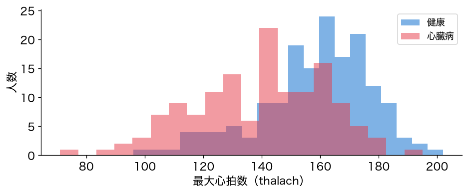

- 心臓病の人（赤）は、左に寄っている

## 1本の列では、分けきれない

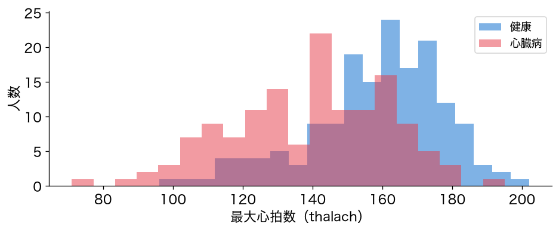

- でも、2つの山は大きく重なる
- 13本の列をまとめて使う

# 2. 確率で当てる

## 13本をまとめて、どう当てる？

- 1本の列では、2つの山が重なった
- これまでは、線形回帰で列をまとめて、数を当ててきた

## 0/1を、直線で当てると？

```python
lin = LinearRegression().fit(Z_tr, y_tr)
p_lin = lin.predict(Z_te)
print(p_lin.min().round(2), p_lin.max().round(2))
```

- これまでの線形回帰で、0/1を当ててみる

## 0〜1から、はみ出す

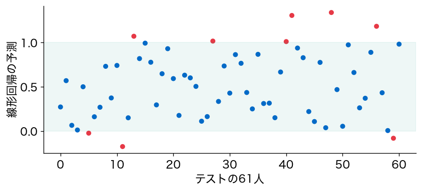

- 最小 −0.18、最大1.34。赤の9人が、0〜1の外

## 確率なら、0〜1に入ってほしい

- 確率が「マイナス」や「1超え」では、意味をなさない
- 直線の値を、0〜1に収めるしくみが要る

## シグモイド関数

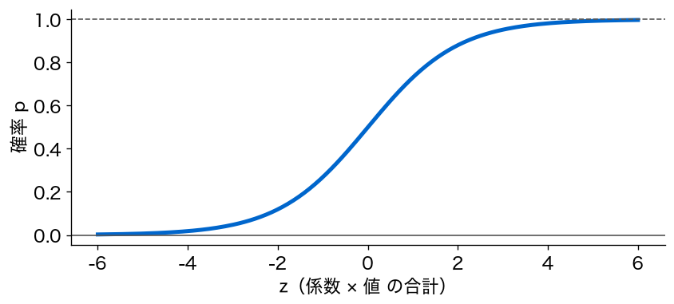

- zがどんなに大きくても小さくても、pは必ず0と1の間

## ロジスティック回帰

- 線形回帰と同じ「係数 × 値の合計」zを計算する
- それをシグモイドで、心臓病である確率にする

## お手本：確率を出す

```python
clf = LogisticRegression(max_iter=5000).fit(Z_tr, y_tr)
prob = clf.predict_proba(Z_te)[:, 1]      # 心臓病である確率
print(prob[:5].round(2))
```

- `predict_proba`は「0の確率」「1の確率」の2列。`[:, 1]`で2列目

## 初めから、罰金がかかっている

- `LogisticRegression`は、初めから係数の二乗の罰金（L2）付き
- 前回のRidgeと同じ罰金。強さは引数`C`
- `C`が小さいほど、罰金が強い（初めは`C=1.0`）

## 変えてみる：LDAでも確率

```python
lda = LinearDiscriminantAnalysis().fit(Z_tr, y_tr)
prob_lda = lda.predict_proba(Z_te)[:, 1]
print(prob_lda[:5].round(2))
```

- 線形判別分析（LDA）：2つのグループの散らばりから、分ける方向を求める

## やってみよう：2節

- 2節の線形回帰、お手本、「変えてみる」のセルを実行する
- 確率は、0〜1に収まっているか？

動画の人は、ここで一時停止。

## 答え合わせ：先頭5人の確率

```
[0.22 0.71 0.06 0.04 0.54]
[0.13 0.64 0.02 0.02 0.5 ]
```

- 上がロジスティック回帰、下がLDA。どちらも0〜1。顔ぶれはほぼ同じ

# 3. 確率を、判定に変える

## 確率のままでは、決まらない

- 精密検査に回すか、回さないか
- 確率が0.5を超えたら心臓病、と決めてみる。この区切りがしきい値

## おさらい：条件で絞る

```python
df[df['price'] <= 100000]      # 10万円以下の部屋だけ
```

- `df[ ]`にTrue/Falseの並びを入れると、Trueの行だけが残る
- 今日は、比べてできたTrue/Falseの並びそのものを使う

## お手本：比べて、判定にする

```python
pred = (prob > 0.5).astype(int)           # 0.5 を超えたら 1（心臓病）
print(pred[:5])
print((pred == y_te).mean().round(3))      # 正解率
```

- 役割：確率を0.5と比べて0/1の判定にし、正解率を出す

## 比べると、True/False

```python
pred = (prob > 0.5).astype(int)           # 0.5 を超えたら 1（心臓病）
```

- 61人それぞれの「0.5を超えるか」が、True/Falseで並ぶ
- `.astype(int)`で、Trueを1、Falseを0に

## meanは、Trueの割合

```python
print((pred == y_te).mean().round(3))      # 正解率
```

- `pred == y_te`は「判定と答えが同じか」のTrue/Falseの並び
- Trueを1、Falseを0として平均すると、Trueの割合＝正解率

## やってみよう：3節

- 3節のお手本のセルを実行する
- 正解率は、いくつか？

動画の人は、ここで一時停止。

## 答え合わせ：正解率0.869

```
[0 1 0 0 1]
0.869
```

- 61人中53人を当てた

# 4. 混同行列

## では、外した8人は？

- 病気の人を「健康」と帰したのか
- 健康な人を「病気」と言ったのか
- 正解率では、区別がつかない

## 判定と答えの、4通り

|  | 判定：健康 | 判定：心臓病 |
| --- | --- | --- |
| 本当は健康 | 真陰性TN | 偽陽性FP（誤検出） |
| 本当は心臓病 | 偽陰性FN（見逃し） | 真陽性TP |

## お手本：真陽性を数える

```python
tp = ((pred == 1) & (y_te == 1)).sum()    # 判定も本当も心臓病
print(tp)
```

- 役割：「判定が1」かつ「本当も1」の人数を数える

## & は「かつ」、sumは数

```python
tp = ((pred == 1) & (y_te == 1)).sum()    # 判定も本当も心臓病
```

- 2つのTrue/Falseの並びを`&`でつなぐと、両方Trueの人だけTrue
- `.sum()`で、Trueの数を数える

## 変えてみる：真陰性を数える

```python
tn = ((pred == 0) & (y_te == 0)).sum()    # 判定も本当も健康
print(tn)
```

- `1`を`0`に変えるだけ

## TODO①：誤検出と見逃しを数える

```python
# TODO: fp と fn を数え、confusion_matrix(y_te, pred) と比べる
# ヒント: fp = ((pred == 1) & (y_te == 0)).sum()
...
```

- `==`の右側の0/1を組み替える

## やってみよう：4節とTODO①

- 4節のお手本と「変えてみる」のセルを実行する
- TODO①：誤検出と見逃しを数え、`confusion_matrix`と比べる

動画の人は、ここで一時停止。

## 答え合わせ：TPとTN

```
TP 26  TN 27
```

- 正しく見つけた26人、正しく健康とした27人

## 答え合わせ：TODO①

```
FP 6  FN 2
[[27  6]
 [ 2 26]]
```

- 誤検出6人、見逃し2人。`confusion_matrix`と一致

## 混同行列を、図で見る

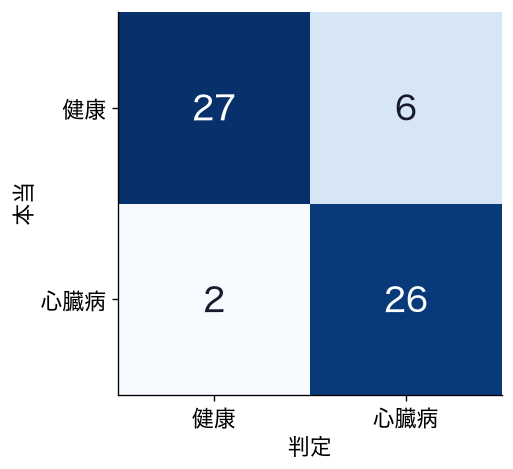

- 行が本当、列が判定。左上からTN・FP、下の段がFN・TP

## 左下が、見逃し

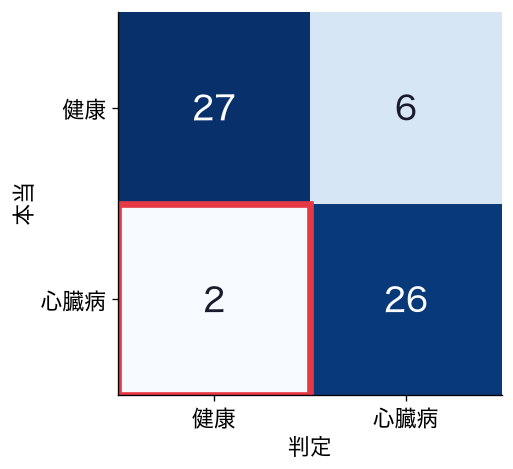

- 本当は心臓病なのに、健康と判定した2人

## 右上が、誤検出

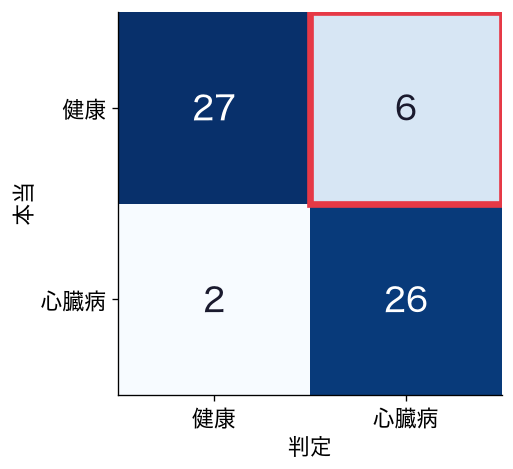

- 本当は健康なのに、心臓病と判定した6人

# 5. 適合率と再現率

## 4つのマスから、物差しを作る

- 見逃し2人、誤検出6人と数えられた
- マスの人数から、目的に合わせた物差しを作る

## 2つの物差し

- 適合率 ＝ TP ÷（TP ＋ FP）：心臓病と判定した人のうち、本当に心臓病だった割合
- 再現率 ＝ TP ÷（TP ＋ FN）：本当に心臓病の人のうち、見つけられた割合

## 何の少なさを測るか

- 適合率：誤検出の少なさ
- 再現率：見逃しの少なさ
- 健診で重いのは、見逃し

## TODO②：式から計算する

```python
# TODO: tp, fp, fn から適合率と再現率を計算する
# ヒント: tp / (tp + fp) が適合率。そのあと
#         classification_report(y_te, pred) で答え合わせ
...
```

## やってみよう：5節とTODO②

- TODO②：適合率と再現率を、式から計算する
- `classification_report`の心臓病の行と、一致するか？

動画の人は、ここで一時停止。

## 答え合わせ：TODO②

```
適合率: 0.81
再現率: 0.93
```

- 適合率26 ÷ 32 ＝ 0.81、再現率26 ÷ 28 ＝ 0.93

## classification_reportと一致

```
              precision    recall  f1-score   support

           0       0.93      0.82      0.87        33
           1       0.81      0.93      0.87        28

    accuracy                           0.87        61
   macro avg       0.87      0.87      0.87        61
weighted avg       0.88      0.87      0.87        61
```

- 心臓病（1）の行のprecisionとrecallが、自分の計算と同じ

## 正解率だけで語らない

- 病気の人が100人中1人なら、「全員健康」で正解率0.99
- でも、再現率は0。1人も見つけていない
- 目的に合った物差しで測る

# 6. ROCとAUC

## 物差しは、0.5で切ったときの値

- 適合率も再現率も、しきい値0.5で判定して数えた

## しきい値は、動かせる

- しきい値を下げれば、見逃しは減り、誤検出は増える
- しきい値を決める前に、2つの方法を比べたい

## 誤検出率：健康な人のうち

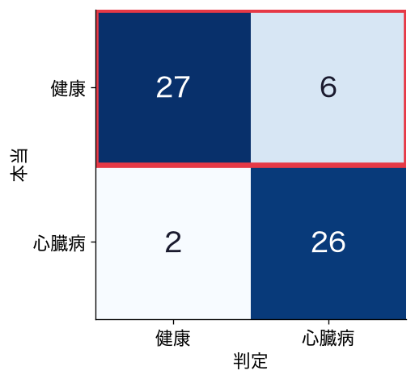

- 誤検出率 ＝ FP ÷（FP ＋ TN）。上の段の中の割合
- しきい値0.5なら、6 ÷ 33 ＝ 0.18

## 検出率：心臓病の人のうち

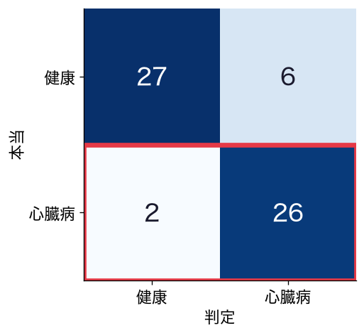

- 検出率 ＝ TP ÷（TP ＋ FN）。下の段の中の割合
- 再現率と同じ。しきい値0.5なら、26 ÷ 28 ＝ 0.93

## ROC曲線

- しきい値を1から0まで全部試す
- 横に誤検出率、縦に検出率（再現率）の点を打って、つなぐ
- 左上に近いほど良い。曲線の下の面積がAUC

## お手本：ROC曲線とAUC

```python
fpr, tpr, _ = roc_curve(y_te, prob)
print(round(roc_auc_score(y_te, prob), 3))
plt.plot(fpr, tpr, lw=2.5, label='ロジスティック回帰')
plt.plot([0, 1], [0, 1], '--', color='gray')      # でたらめな判定
plt.xlabel('誤検出率'); plt.ylabel('検出率（再現率）'); plt.legend()
plt.show()
```

## TODO③：LDAのAUCと比べる

```python
# TODO: roc_auc_score で LDA の AUC を出し、ロジスティック回帰と比べる
# ヒント: お手本の prob を prob_lda に変える
...
```

## やってみよう：6節とTODO③

- 6節のお手本のセルを実行する
- TODO③：LDAのAUCを出して比べる

動画の人は、ここで一時停止。

## 答え合わせ：ROC曲線

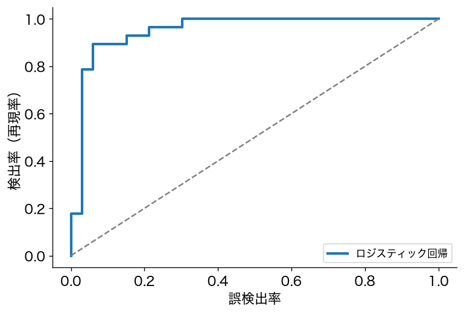

- 曲線は、左上にぐっと寄っている。点線はでたらめな判定

## AUCは0.951

```
0.951
```

- 1に近いほど良い。でたらめなら0.5

## 答え合わせ：TODO③

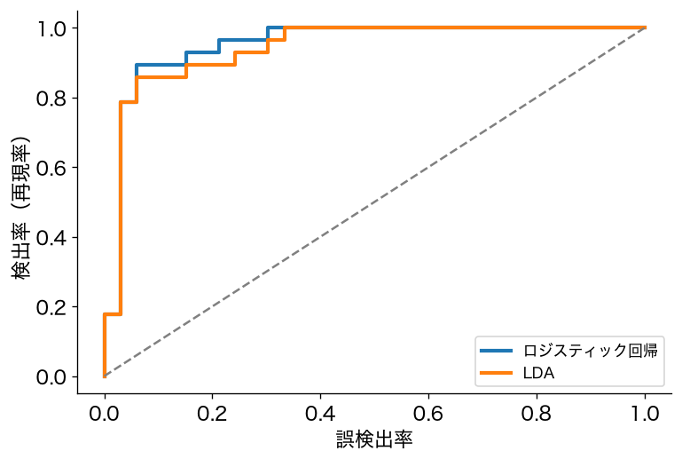

- LDAのAUCは0.940。2本の曲線は、ほぼ重なる

## 考え方の違う2つが、同じくらい

- ロジスティック回帰とLDAは、確率の出し方の考え方が違う
- それでも、同じくらいよく分けられた

## 0.011の差は、どれくらい？

- AUCは、心臓病の人と健康な人の組のうち、心臓病の人の確率が高い組の割合
- 組は、28人 × 33人 ＝ 924組

## 924組のうち、約10組

- 差の0.011は、924組のうち、約10組の違い

## 61人では、運の範囲

- 61人のテストでは、約10組の差は運の範囲

# 7. 答えを出す

## 物差しはそろった。答えを出す

- 混同行列、適合率と再現率、AUCで、判定を測れた
- 今日の問いに、数で答える

## お手本：見逃しを文にする

```python
fn = ((pred == 0) & (y_te == 1)).sum()    # 見逃し（TODO①と同じ）
n_sick = tp + fn                          # 本当に心臓病の人
print(f'心臓病の{n_sick}人のうち{tp}人を見つけ、{fn}人を見逃した'
      f'（再現率 {tp / n_sick:.2f}）')
```

- 役割：混同行列の数から、見逃しをf-stringで文にする

## TODO④：誤検出も文にする

```python
# TODO: 健康な人のうち、誤って心臓病と判定した人数を文にする
# ヒント: fp = ((pred == 1) & (y_te == 0)).sum()、n_ok = tn + fp、
#         お手本の f-string をまねる
...
```

## やってみよう：7節とTODO④

- 7節のお手本のセルを実行する
- TODO④：誤検出の人数を文にする

動画の人は、ここで一時停止。

## 答え合わせ：見逃し

```
心臓病の28人のうち26人を見つけ、2人を見逃した（再現率 0.93）
```

## 答え合わせ：TODO④

```
健康な33人のうち6人を、心臓病と判定した（誤検出）
```

## 医師の答え

しきい値0.5なら、心臓病の28人のうち26人を見つけ、2人を見逃す。健康な33人のうち6人は、精密検査に回る。

## まだ言えないこと①：しきい値

- 見逃し2人を0人にするには、しきい値をどこまで下げればよいか

## まだ言えないこと②：番号の区分

- 胸の痛みの型（`cp`）などは、区分なのに、数のまま入れている

# まとめ

## 今日の歩み

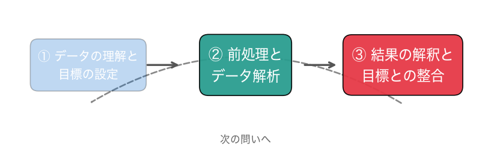

確率で当てる → 判定にする → 4つのマスを数える → 適合率と再現率 → ROC

## 今日の要点

- 0/1を直線で当てるとはみ出す。ロジスティック回帰はシグモイドで確率に
- 確率をしきい値と比べて判定。正解率はTrueの割合
- 混同行列の4つのマス。見逃しと誤検出は重さが違う
- 適合率は誤検出の少なさ、再現率は見逃しの少なさ
- ROC曲線はしきい値を動かした誤検出率と検出率。下の面積AUCで比べる
- Python：比べてTrue/False、`&`で重ね、`.sum()`で数、`.mean()`で割合

## 課題の出し方

- ノートの最後の「課題（提出）」に取り組む
- 応用②の答えと応用③の文章を、LACSに入力して提出（＝出席。期限なし）
- AIを使ってもよい。何を聞いて、どう直したかを1行書く

## 次回予告：しきい値を決める

- 今日は、しきい値0.5で判定し、2人を見逃した
- 次回は、新しい受診者も、同じ手順で判定する

## 次回の問い

どの確率から、精密検査に回すか？

## このあと：課題へ

ノートの「課題（提出）」へ。検査値を3本に減らしたら、見逃しは何人になるか。